# Tornados are the most harmful weather events for human health but floods cause the worst economic effect

attila.toth86

20 Aug 2015

# Synopsis

*This document is created for the “Peer Assessment 2” assignment in the framework of Reproducible Research online course provided by Johns Hopkins University on Coursera.*

Storms and other severe weather events can cause both public health and economic problems for communities and municipalities. Many severe events can result in fatalities, injuries, and property damage, and preventing such outcomes to the extent possible is a key concern.

The ultimate goal of this assignment is to explore the NOAA Storm Database and answer the following questions about severe weather events:

Across the United States,

1. which types of events are most harmful with respect to population health?
2. which types of events have the greatest economic consequences?

# Data Processing

## Data Description

This project involves exploring the U.S. National Oceanic and Atmospheric Administration’s (NOAA) storm database. This database tracks characteristics of major storms and weather events in the United States, including when and where they occur, as well as estimates of any fatalities, injuries, and property damage.

The data come in the form of a comma-separated-value file compressed via the bzip2 algorithm to reduce its size. Data is available for download [here](https://d396qusza40orc.cloudfront.net/repdata%2Fdata%2FStormData.csv.bz2).

There is some documentation of the database available. Here you will find how some of the variables are constructed/defined.

- National Weather Service [Storm Data Documentation](https://d396qusza40orc.cloudfront.net/repdata%2Fpeer2_doc%2Fpd01016005curr.pdf)
- National Climatic Data Center Storm Events [FAQ](https://d396qusza40orc.cloudfront.net/repdata%2Fpeer2_doc%2FNCDC%20Storm%20Events-FAQ%20Page.pdf)

The events in the database start in the year 1950 and end in November 2011. In the earlier years of the database there are generally fewer events recorded, most likely due to a lack of good records. More recent years should be considered more complete.

## Data Loading & Transformation

I first downloaded the NOAA database from course’s website.

```r
if(!file.exists("StormData.csv.bz2")) {
    download.file(url = "https://d396qusza40orc.cloudfront.net/repdata%2Fdata%2FStormData.csv.bz2",
                  destfile = "StormData.csv.bz2", method = "curl")
}
```

After downloading I read in the given data from the file archive. read.csv() function can handle bzip files so no preliminary unzipping was required.

```r
stormdata <- read.csv("StormData.csv.bz2")
```

A high level overview of the database shows that it consists of 902297 rows & 37 columns (variables):

```r
str(stormdata)
```

```
## 'data.frame':    902297 obs. of  37 variables:
##  $ STATE__   : num  1 1 1 1 1 1 1 1 1 1 ...
##  $ BGN_DATE  : Factor w/ 16335 levels "1/1/1966 0:00:00",..: 6523 6523 4242 11116 2224 2224 2260 383 3980 3980 ...
##  $ BGN_TIME  : Factor w/ 3608 levels "00:00:00 AM",..: 272 287 2705 1683 2584 3186 242 1683 3186 3186 ...
##  $ TIME_ZONE : Factor w/ 22 levels "ADT","AKS","AST",..: 7 7 7 7 7 7 7 7 7 7 ...
##  $ COUNTY    : num  97 3 57 89 43 77 9 123 125 57 ...
##  $ COUNTYNAME: Factor w/ 29601 levels "","5NM E OF MACKINAC BRIDGE TO PRESQUE ISLE LT MI",..: 13513 1873 4598 10592 4372 10094 1973 23873 24418 4598 ...
##  $ STATE     : Factor w/ 72 levels "AK","AL","AM",..: 2 2 2 2 2 2 2 2 2 2 ...
##  $ EVTYPE    : Factor w/ 985 levels "   HIGH SURF ADVISORY",..: 834 834 834 834 834 834 834 834 834 834 ...
##  $ BGN_RANGE : num  0 0 0 0 0 0 0 0 0 0 ...
##  $ BGN_AZI   : Factor w/ 35 levels "","  N"," NW",..: 1 1 1 1 1 1 1 1 1 1 ...
##  $ BGN_LOCATI: Factor w/ 54429 levels ""," Christiansburg",..: 1 1 1 1 1 1 1 1 1 1 ...
##  $ END_DATE  : Factor w/ 6663 levels "","1/1/1993 0:00:00",..: 1 1 1 1 1 1 1 1 1 1 ...
##  $ END_TIME  : Factor w/ 3647 levels ""," 0900CST",..: 1 1 1 1 1 1 1 1 1 1 ...
##  $ COUNTY_END: num  0 0 0 0 0 0 0 0 0 0 ...
```

[output cut: 23 more lines]

From which my presumption is that answering the given questions following variables might be required:

- EVTYPE
- FATALITIES
- INJURIES
- PROPDMG
- PROPDMGEXP
- CROPDMG
- CROPDMGEXP

EVTYPE variable most likely gives us the observed and recorded events’ type.

```r
summary(stormdata$EVTYPE)
```

```
##                     HAIL                TSTM WIND        THUNDERSTORM WIND
##                   288661                   219940                    82563
##                  TORNADO              FLASH FLOOD                    FLOOD
##                    60652                    54277                    25326
##       THUNDERSTORM WINDS                HIGH WIND                LIGHTNING
##                    20843                    20212                    15754
##               HEAVY SNOW               HEAVY RAIN             WINTER STORM
##                    15708                    11723                    11433
##           WINTER WEATHER             FUNNEL CLOUD         MARINE TSTM WIND
##                     7026                     6839                     6175
## MARINE THUNDERSTORM WIND               WATERSPOUT              STRONG WIND
##                     5812                     3796                     3566
##     URBAN/SML STREAM FLD                 WILDFIRE                 BLIZZARD
##                     3392                     2761                     2719
##                  DROUGHT                ICE STORM           EXCESSIVE HEAT
##                     2488                     2006                     1678
##               HIGH WINDS         WILD/FOREST FIRE             FROST/FREEZE
##                     1533                     1457                     1342
##                DENSE FOG       WINTER WEATHER/MIX           TSTM WIND/HAIL
##                     1293                     1104                     1028
##  EXTREME COLD/WIND CHILL                     HEAT                HIGH SURF
##                     1002                      767                      725
##           TROPICAL STORM           FLASH FLOODING             EXTREME COLD
##                      690                      682                      655
##            COASTAL FLOOD         LAKE-EFFECT SNOW        FLOOD/FLASH FLOOD
##                      650                      636                      624
##                LANDSLIDE                     SNOW          COLD/WIND CHILL
##                      600                      587                      539
##                      FOG              RIP CURRENT              MARINE HAIL
##                      538                      470                      442
##               DUST STORM                AVALANCHE                     WIND
##                      427                      386                      340
##             RIP CURRENTS              STORM SURGE            FREEZING RAIN
##                      304                      261                      250
##              URBAN FLOOD     HEAVY SURF/HIGH SURF        EXTREME WINDCHILL
##                      249                      228                      204
##             STRONG WINDS           DRY MICROBURST    ASTRONOMICAL LOW TIDE
##                      196                      186                      174
##                HURRICANE              RIVER FLOOD               LIGHT SNOW
##                      174                      173                      154
```

[output cut: 13 more lines]

```
##                       64                       61                       61
##      TROPICAL DEPRESSION                    SLEET         UNSEASONABLY DRY
##                       60                       59                       56
##                    FROST              GUSTY WINDS      THUNDERSTORM WINDSS
##                       53                       53                       51
##       MARINE STRONG WIND                    OTHER               SMALL HAIL
##                       48                       48                       47
##                   FUNNEL             FREEZING FOG             THUNDERSTORM
##                       46                       45                       45
##       Temperature record          TSTM WIND (G45)         Coastal Flooding
##                       43                       39                       38
##              WATERSPOUTS    MONTHLY PRECIPITATION                    WINDS
##                       37                       36                       36
##                  (Other)
##                     2940
```

FATALITIES & INJURIES seem to be numeric variables that indicate the number of recorded human fatalities/injuries occured in recorded events.

```r
summary(stormdata$FATALITIES)
```

```
##     Min.  1st Qu.   Median     Mean  3rd Qu.     Max.
##   0.0000   0.0000   0.0000   0.0168   0.0000 583.0000
```

```r
summary(stormdata$INJURIES)
```

```
##      Min.   1st Qu.    Median      Mean   3rd Qu.      Max.
##    0.0000    0.0000    0.0000    0.1557    0.0000 1700.0000
```

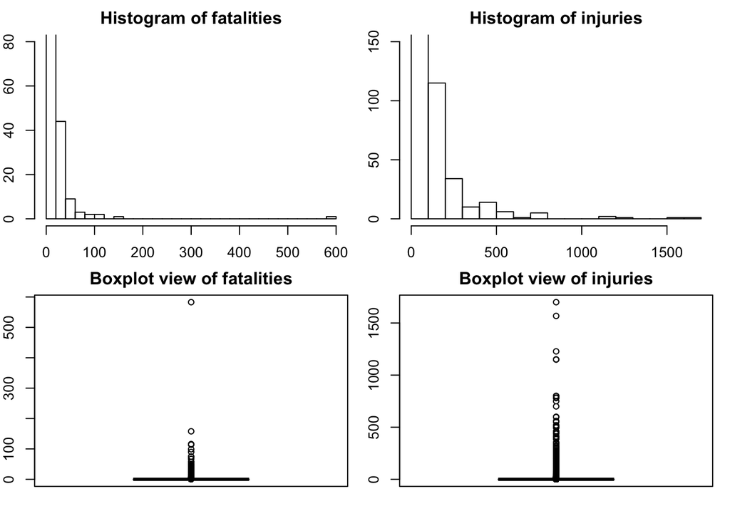

```r
par(mfrow = c(2,2), mar = c(2,2,2,1))
hist(stormdata$FATALITIES, main = "Histogram of fatalities", ylim=c(0,80), xlab="")
hist(stormdata$INJURIES, main = "Histogram of injuries", ylim=c(0,150), xlab="")
boxplot(stormdata$FATALITIES, main = "Boxplot view of fatalities")
boxplot(stormdata$INJURIES, main = "Boxplot view of injuries")
```

Vast majority of recorded events do not have any effect on human’s health.

PROPDMG (together with PROPDMGEXP) variable somehow refers to the value of property damage, CROPDMG (together with CROPDMGEXP) variable to the value of crop damage recorded in correspondence with a certain event.

```r
summary(stormdata$PROPDMG)
```

```
##    Min. 1st Qu.  Median    Mean 3rd Qu.    Max.
##    0.00    0.00    0.00   12.06    0.50 5000.00
```

```r
summary(stormdata$CROPDMG)
```

```
##    Min. 1st Qu.  Median    Mean 3rd Qu.    Max.
##   0.000   0.000   0.000   1.527   0.000 990.000
```

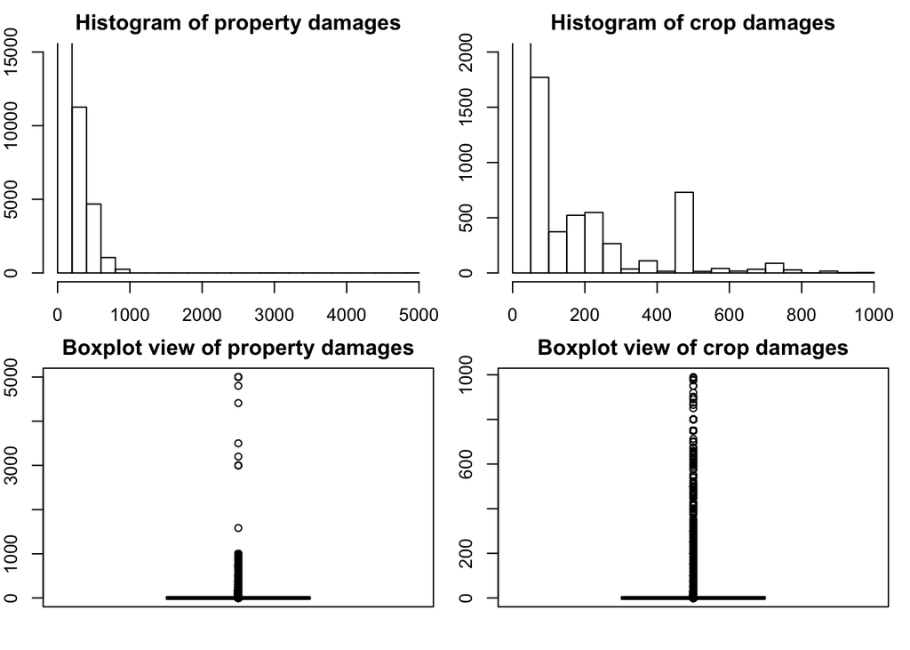

```r
par(mfrow = c(2,2), mar = c(2,2,2,1))
hist(stormdata$PROPDMG, main = "Histogram of property damages", xlab="", ylim=c(0,15000))
hist(stormdata$CROPDMG, main = "Histogram of crop damages", xlab="", ylim=c(0,2000))
boxplot(stormdata$PROPDMG, main = "Boxplot view of property damages")
boxplot(stormdata$CROPDMG, main = "Boxplot view of crop damages")
```

Similarly to fatalities & injuries, most of recorded events do not have any economic effect.

PROPDMG & CROPDMG are numeric variables but alone they do not say much about damage extent they measure. For appropriate analysis I would need to know the unit that they are measured in. For this PROPDMGEXP & CROPDMGEXP variables seem to be the right choice despite the experienced data quality issues in these columns. Value set for these columns in the database:

```r
unique(stormdata$PROPDMGEXP)
```

```
##  [1] K M   B m + 0 5 6 ? 4 2 3 h 7 H - 1 8
## Levels:  - ? + 0 1 2 3 4 5 6 7 8 B h H K m M
```

```r
unique(stormdata$CROPDMGEXP)
```

```
## [1]   M K m B ? 0 k 2
## Levels:  ? 0 2 B k K m M
```

To narrow the dataset I have to work with I performed the following filters:

- Selected only relevant columns: BGN_DATE, EVTYPE, FATALITIES, INJURIES, PROPDMG, PROPDMGEXP, CROPDMG, CROPDMGEXP
- Filtered out those records that have no effect on human health & economy. (All relevant variables show zero.)

```r
library(dplyr)
sdata_n <- stormdata %>%
            filter(
                !(FATALITIES == 0 &
                INJURIES == 0 &
                PROPDMG == 0 &
                CROPDMG == 0)
                ) %>%
            select(BGN_DATE, EVTYPE, FATALITIES, INJURIES, PROPDMG, PROPDMGEXP, CROPDMG, CROPDMGEXP)
```

Take a look at ‘EXP’ variables after filtering:

```r
sdata_n %>% group_by(PROPDMGEXP) %>% summarise(CNT=n())
```

```
## Source: local data frame [16 x 2]
##
##    PROPDMGEXP    CNT
## 1              11585
## 2           -      1
## 3           +      5
## 4           0    210
## 5           2      1
## 6           3      1
## 7           4      4
## 8           5     18
## 9           6      3
## 10          7      3
## 11          B     40
## 12          h      1
## 13          H      6
## 14          K 231428
## 15          m      7
## 16          M  11320
```

```r
sdata_n %>% group_by(CROPDMGEXP) %>% summarise(CNT=n())
```

```
## Source: local data frame [8 x 2]
##
##   CROPDMGEXP    CNT
## 1            152664
## 2          ?      6
## 3          0     17
## 4          B      7
## 5          k     21
## 6          K  99932
## 7          m      1
## 8          M   1985
```

There is no unambiguous information available about the coding so I first ignored the case of the letters then I assume the following value mappings applicable for these variables:

- “H” = hundred USD
- “K” = thousand USD
- “M” = million USD
- “B” = billion USD

The rest of the coding is unknown. I checked the extent of these values in light of their frequency & their correspondent value in the related variables (filtered out those records where the value field contains zero since there is no effect for those items whatever the ‘EXP’ columns’ value set represents):

```r
sdata_n %>% filter(PROPDMG!=0) %>% group_by(PROPDMGEXP) %>% summarise(CNT = n(),SUM = sum(PROPDMG)) %>% mutate(PERCENT_FREQ = round(CNT/sum(CNT)*100,2), PERCENT_VALUE = round(SUM/sum(SUM)*100,2))
```

```
## Source: local data frame [16 x 5]
##
##    PROPDMGEXP    CNT         SUM PERCENT_FREQ PERCENT_VALUE
## 1                 76      527.41         0.03          0.00
## 2           -      1       15.00         0.00          0.00
## 3           +      5      117.00         0.00          0.00
## 4           0    209     7108.30         0.09          0.07
## 5           2      1       12.00         0.00          0.00
## 6           3      1       20.00         0.00          0.00
## 7           4      4       14.50         0.00          0.00
## 8           5     18      210.50         0.01          0.00
## 9           6      3       65.00         0.00          0.00
## 10          7      2       82.00         0.00          0.00
## 11          B     40      275.85         0.02          0.00
## 12          h      1        2.00         0.00          0.00
## 13          H      6       25.00         0.00          0.00
## 14          K 227481 10735292.10        95.11         98.63
## 15          m      7       38.90         0.00          0.00
## 16          M  11319   140694.45         4.73          1.29
```

```r
sdata_n %>% filter(CROPDMG!=0) %>% group_by(CROPDMGEXP) %>% summarise(CNT = n(),SUM = sum(CROPDMG)) %>% mutate(PERCENT_FREQ = round(CNT/sum(CNT)*100,2), PERCENT_VALUE = round(SUM/sum(SUM)*100,2))
```

```
## Source: local data frame [7 x 5]
##
##   CROPDMGEXP   CNT        SUM PERCENT_FREQ PERCENT_VALUE
## 1                3      11.00         0.01          0.00
## 2          0    12     260.00         0.05          0.02
## 3          B     7      13.61         0.03          0.00
## 4          k    21     436.00         0.10          0.03
## 5          K 20137 1342955.91        91.12         97.47
## 6          m     1      10.00         0.00          0.00
## 7          M  1918   34140.80         8.68          2.48
```

Looking at the frequency & extent of wrong codes, I believe, either exclusion or recoding would not affect my final result significantly, i.e. less the 1% is the occurence of unknown codes in the entire population. Therefore I decided to exclude these items from further analysis.

I translated the codes (H, K, M, B) to numeric format to use them as a multipicator of PROPDMG & CROPDMG variables in order to arrive to PROPDMGUSD & CROPDMGUSD variables that show the damage amount in a unified USD format throughout the entire database (e.g. PROPDMG = 25, PROPDMGEXP = K -> PROPDMGUSD = 25000). Problematic codes were simply translated to 0 (zero) so their multipicator effect will zero out the correspondent damage values.

For code translation I made use of *decode* function, created by [flodel](https://gist.github.com/flodel/4470993#file-decode-r).

Function description:

```r
decode <- function(x, search, replace, default = NULL) {
    decode.fun <- function(search, replace, default = NULL)
        if (length(search) == 0L) {
            function(x) if (is.null(default)) x else rep(default, length(x))
        } else {
            function(x) ifelse(x == search[1L], replace[1L],
                               decode.fun(tail(search,  -1L),
                                          tail(replace, -1L),
                                          default)(x))
        }
    return(decode.fun(search, replace, default)(x))
}
```

Code translation & some date formatting:

```r
sdata_clean  <- sdata_n %>%
                mutate(PROPDMGUSD = decode(toupper(PROPDMGEXP),
                                            c("K","M","B","H"),
                                            c(1000,1000000,1000000000,100),
                                            0)*PROPDMG,
                       CROPDMGUSD = decode(toupper(CROPDMGEXP),
                                            c("K","M","B","H"),
                                            c(1000,1000000,1000000000,100),
                                            0)*CROPDMG,
                       PROPDMGEXP = decode(toupper(PROPDMGEXP),
                                            c("K","M","B","H"),
                                            c("K","M","B","H"),
                                            NA),
                       CROPDMGEXP = decode(toupper(CROPDMGEXP),
                                            c("K","M","B","H"),
                                            c("K","M","B","H"),
                                            NA),
                       DATE = as.Date(as.character(BGN_DATE),"%m/%d/%Y")
                    ) %>%
                select(DATE,
                       EVTYPE,
                       FATALITIES,
                       INJURIES,
                       PROPDMG,
                       PROPDMGEXP,
                       PROPDMGUSD,
                       CROPDMG,
                       CROPDMGEXP,
                       CROPDMGUSD
                       )
str(sdata_clean)
```

```
## 'data.frame':    254633 obs. of  10 variables:
##  $ DATE      : Date, format: "1950-04-18" "1950-04-18" ...
##  $ EVTYPE    : Factor w/ 985 levels "   HIGH SURF ADVISORY",..: 834 834 834 834 834 834 834 834 834 834 ...
##  $ FATALITIES: num  0 0 0 0 0 0 0 0 1 0 ...
##  $ INJURIES  : num  15 0 2 2 2 6 1 0 14 0 ...
##  $ PROPDMG   : num  25 2.5 25 2.5 2.5 2.5 2.5 2.5 25 25 ...
##  $ PROPDMGEXP: chr  "K" "K" "K" "K" ...
##  $ PROPDMGUSD: num  25000 2500 25000 2500 2500 2500 2500 2500 25000 25000 ...
##  $ CROPDMG   : num  0 0 0 0 0 0 0 0 0 0 ...
##  $ CROPDMGEXP: chr  NA NA NA NA ...
##  $ CROPDMGUSD: num  0 0 0 0 0 0 0 0 0 0 ...
```

# Results

## Most harmful events for population health

In my analysis I consider those events harmful that resulted any fatality or injury. Since 1950 **in 6974 events** were reported that resulted one or more people’s death. In these cases a total of **15145 people deceased**. **Injuries** occured more often, **reported 17604 times in which 140528 people were involved.**

**Total number of events that have effect on human health counts 21929 in which 155673 people were involved.**

I sumed fatalities & injuries by event type and listed them in a decreasing order of total number of people involved.

Top 10 events with regard to fatalities:

```r
evtype_fat_sum <-   sdata_clean %>%
                    group_by(EVTYPE) %>%
                    summarise(TOTAL_FATALITIES=sum(FATALITIES)) %>%
                    mutate(PERCENT = round(100*TOTAL_FATALITIES/sum(TOTAL_FATALITIES),2)) %>%
                    arrange(desc(TOTAL_FATALITIES))
evtype_fat_sum[1:10,]
```

```
## Source: local data frame [10 x 3]
##
##            EVTYPE TOTAL_FATALITIES PERCENT
## 1         TORNADO             5633   37.19
## 2  EXCESSIVE HEAT             1903   12.57
## 3     FLASH FLOOD              978    6.46
## 4            HEAT              937    6.19
## 5       LIGHTNING              816    5.39
## 6       TSTM WIND              504    3.33
## 7           FLOOD              470    3.10
## 8     RIP CURRENT              368    2.43
## 9       HIGH WIND              248    1.64
## 10      AVALANCHE              224    1.48
```

Top 10 events with regard to injuries:

```r
evtype_inj_sum <-   sdata_clean %>%
                    group_by(EVTYPE) %>%
                    summarise(TOTAL_INJURIES=sum(INJURIES)) %>%
                    mutate(PERCENT = round(100*TOTAL_INJURIES/sum(TOTAL_INJURIES),2)) %>%
                    arrange(desc(TOTAL_INJURIES))
evtype_inj_sum[1:10,]
```

```
## Source: local data frame [10 x 3]
##
##               EVTYPE TOTAL_INJURIES PERCENT
## 1            TORNADO          91346   65.00
## 2          TSTM WIND           6957    4.95
## 3              FLOOD           6789    4.83
## 4     EXCESSIVE HEAT           6525    4.64
## 5          LIGHTNING           5230    3.72
## 6               HEAT           2100    1.49
## 7          ICE STORM           1975    1.41
## 8        FLASH FLOOD           1777    1.26
## 9  THUNDERSTORM WIND           1488    1.06
## 10              HAIL           1361    0.97
```

**What clearly seems from these numbers is that tornados can be considered as most dangerous weather events in respect of human health.**

## Events with greatest economic consequences

In order to answer the question of which weather event has the greatest economic consequences, I needed to create the measurement of economic effect. In my analysis this measure is simply the sum amount of damages occured in properties & crop together. Since 1950, **244722 weather events were registered that resulted any economic damage**.

If I group the data by event type and sum the total damage (in property & crop) I will get to the conclusion that **floods (followed by hurricanes/typhoons) caused the most significant economic loss.**

Top 10 events in respect of economy damage:

```r
sdata_c_eco <-  sdata_clean %>%
                mutate(TOTAL_DMG_USD = PROPDMGUSD+CROPDMGUSD) %>%
                group_by(EVTYPE) %>%
                summarise(TOTDMG = sum(TOTAL_DMG_USD)) %>%
                mutate(PERCENT = round(100*TOTDMG/sum(TOTDMG),2)) %>%
                arrange(desc(TOTDMG))
sdata_c_eco[1:10,]
```

```
## Source: local data frame [10 x 3]
##
##               EVTYPE       TOTDMG PERCENT
## 1              FLOOD 150319678250   31.55
## 2  HURRICANE/TYPHOON  71913712800   15.09
## 3            TORNADO  57352113590   12.04
## 4        STORM SURGE  43323541000    9.09
## 5               HAIL  18758221670    3.94
## 6        FLASH FLOOD  17562128610    3.69
## 7            DROUGHT  15018672000    3.15
## 8          HURRICANE  14610229010    3.07
## 9        RIVER FLOOD  10148404500    2.13
## 10         ICE STORM   8967041310    1.88
```